# WQD7004 2024/2025 Sem2 - Group G03

2025-06-01

WQD7004 Group Project - OCC1 - Group G03

Richie Teoh (24088171)  
Elmer Lee Jia Zhao (24082366)  
Micole Chung Syn Tung (24073625)  
Lee Re Xuan (24071969)  
Angeline Tan Jie Lin (24084444)

01 June 2025

# Introduction

As Kuala Lumpur and Selangor continue to develop, they attract many young professionals and individuals from other states seeking better career opportunities. With the rising cost of living—particularly in Kuala Lumpur—renting has become a more practical choice, especially for newcomers to the urban workforce.

Proximity to public transport such as LRT, MRT, and KTM is a key factor in rental decisions, helping tenants save on transport costs. Rental prices vary widely depending on location, unit size, furnishing, and amenities. For instance, apartments in Bangsar South typically start from RM2,000 (PropertyGuru, 2024; EdgeProp, 2024).

This project analyzes apartment rental listings from *mudah.my* in Kuala Lumpur and Selangor to uncover key pricing patterns. A regression model will be used to predict rental prices, while a classification model will explore furnishing status based on property features. The findings aim to support better decision-making for both tenants and property owners.

## Title

- Prediction of Rental Price via Regression and Classification of Property Furnishing Level in Klang Valley, Malaysia.

## Questions

- The purpose of processing this dataset is to identify and understand the factors that influence apartment rental prices in Kuala Lumpur and Selangor. By analyzing various features of rental listings, such as property size, location, number of rooms, furnishing status, and proximity to transportation, the project aims to uncover patterns within the rental market and derive predictive insights.

  This project focuses on addressing two key analytical questions:
  1. What are the key factors that influence rental prices, and how can rental prices be predicted using property features?

  ```
  -   This question is approached using regression analysis. The objective is to construct a predictive model that estimates rental prices based on selected variables such as square footage, number of bedrooms, floor level, and furnishing status. The model is intended to provide a quantitative underst…
  ```

  2. Can the furnishing status of an apartment (i.e., fully furnished, partially furnished, or unfurnished) be predicted based on other property characteristics?

  ```
  -   This question is addressed using classification techniques. The objective is to develop a model that classifies rental listings into one of the three furnishing categories based on features such as rental price, location, property size, and number of bedrooms and bathrooms. This classification p…
  ```

## Project Goal

- This project aims to analyze apartment rental listings from Kuala Lumpur and Selangor using data sourced from *mudah.my*. The main objectives are:
1. To clean and preprocess the dataset to ensure consistency, accuracy, and readiness for analysis by handling missing values, formatting issues, and irrelevant variables.
2. To develop a regression model that predicts apartment rental prices based on key property features such as size, location, number of rooms, and furnishing status.
3. To develop a classification model that predicts the furnishing status of an apartment unit (i.e. fully furnished, partially furnished, or unfurnished) based on property features such as size, location, number of bedrooms, and rental price.

```r
# Load required libraries for data manipulation, visualization, and machine learning
library(tidyverse)
```

```r
library(dplyr)
library(stringr)
library(ggplot2)
library(reshape2)
library(caret)
library(xgboost)
library(lightgbm)
library(nnet)
```

```r
# Load the dataset
df <- read.csv('mudah-apartment-kl-selangor.csv')
head(df)
```

```
##      ads_id                     prop_name completion_year       monthly_rent
## 1 100323185      The Hipster @ Taman Desa            2022 RM 4 200 per month
## 2 100203973                  Segar Courts              NA RM 2 300 per month
## 3 100323128 Pangsapuri Teratak Muhibbah 2              NA RM 1 000 per month
## 4 100191767  Sentul Point Suite Apartment            2020 RM 1 700 per month
## 5  97022692               Arte Mont Kiara              NA RM 1 299 per month
## 6 100322897      Residensi Vista Wirajaya              NA RM 1 500 per month
##                    location     property_type rooms parking bathroom
## 1 Kuala Lumpur - Taman Desa       Condominium     5       2        6
## 2     Kuala Lumpur - Cheras       Condominium     3       1        2
## 3 Kuala Lumpur - Taman Desa         Apartment     3      NA        2
## 4     Kuala Lumpur - Sentul         Apartment     2       1        2
## 5 Kuala Lumpur - Mont Kiara Service Residence     1       1        1
## 6    Kuala Lumpur - Setapak         Apartment     3       1        2
##          size           furnished
```

[output cut: 20 more lines]

```r
# Create a metadata table describing each key column
metadata <- tibble(
  Column_Name = c(
    "ads_id",
    "prop_name",
    "completion_year",
    "monthly_rent",
    "location",
    "property_type",
    "rooms",
    "parking",
    "bathroom",
    "size",
    "furnished",
    "facilities",
    "additional_facilities"
  ),
  Description = c(
    "Unique identifier for the listing",
    "Name of the building/property",
    "Completion/established year of the property",
    "Monthly rent in Ringgit Malaysia (RM)",
    "Property location within Kuala Lumpur region",
    "Type of property (apartment, condo, flat, etc.)",
    "Number of rooms in the unit",
    "Number of parking spaces for the unit",
    "Number of bathrooms in the unit",
    "Total area of the unit in square feet",
    "Furnishing status of the unit (fully, partial, non-furnished)",
    "Main facilities available",
    "Additional facilities (e.g., proximity to mall, school, railway, etc.)"
  )
)

# Print the metadata table
metadata
```

```
## # A tibble: 13 × 2
##    Column_Name           Description
##    <chr>                 <chr>
##  1 ads_id                Unique identifier for the listing
##  2 prop_name             Name of the building/property
##  3 completion_year       Completion/established year of the property
##  4 monthly_rent          Monthly rent in Ringgit Malaysia (RM)
##  5 location              Property location within Kuala Lumpur region
##  6 property_type         Type of property (apartment, condo, flat, etc.)
##  7 rooms                 Number of rooms in the unit
##  8 parking               Number of parking spaces for the unit
##  9 bathroom              Number of bathrooms in the unit
## 10 size                  Total area of the unit in square feet
## 11 furnished             Furnishing status of the unit (fully, partial, non-fur…
## 12 facilities            Main facilities available
## 13 additional_facilities Additional facilities (e.g., proximity to mall, school…
```

From the metadata extracted from Kaggle above: - ads_id should be dropped as it is a unique identifier for the Mudah rental listing. - prop_name can influence the rental price, for example properties under well-known developers such as Arte tend to be higher-priced; however, it does not generalize well and unseen property names might cause issues in the model. Henceforth, we decide to drop this variable as well. - completion_year includes some NA values, will investigate further, completion_year contributes to the price and the info are usually available online, hence we will impute it manually from data found online. - monthly_rent is saved as chr type due to the “RM” prefixes, will perform appropriate data transformation. - size is saved as chr type due to the “sq. ft.” suffixes, will perform appropriate data transformation.

# Data Pre-processing

The dataset was filtered to include only listings labeled as “Serviced Residences” or “Condominium” to reduce noise and focus the analysis on high-rise residential properties. Duplicate entries based on `ads_id` were removed by retaining only the row with the least number of missing values, ensuring cleaner and more reliable input for modeling.

```r
# Data Pre-processing

# Filter only serviced residences and condo
df <- df %>%
  filter(.data[['property_type']] %in% c('Service Residence','Condominium'))

# Check and Remove duplicated values.
duplicates_only <- df %>%
  filter(duplicated(df) | duplicated(df, fromLast = TRUE)) %>%
  arrange(ads_id)

duplicates_ads_id <- df %>%
  filter(duplicated(df['ads_id']) | duplicated(df['ads_id'], fromLast = TRUE)) %>%
  arrange(ads_id)

head(duplicates_only)
```

```
##      ads_id                            prop_name completion_year
## 1 100108343                The Glenz @ Glenmarie              NA
## 2 100108343                The Glenz @ Glenmarie              NA
## 3 100304102 Impiria Residensi Bukit Tinggi Klang            2018
## 4 100304102 Impiria Residensi Bukit Tinggi Klang            2018
## 5 100640316            Hill10 Residence @ i-City              NA
## 6 100640316            Hill10 Residence @ i-City              NA
##         monthly_rent              location     property_type rooms parking
## 1 RM 1 800 per month Selangor - Setia Alam Service Residence   2.0      NA
## 2 RM 1 800 per month Selangor - Setia Alam Service Residence   2.0      NA
## 3 RM 3 300 per month      Selangor - Klang Service Residence   4.0      NA
## 4 RM 3 300 per month      Selangor - Klang Service Residence   4.0      NA
## 5 RM 2 500 per month  Selangor - Shah Alam Service Residence   2.0      NA
## 6 RM 2 500 per month  Selangor - Shah Alam Service Residence   2.0      NA
##   bathroom        size           furnished
```

[output cut: 20 more lines]

```r
head(duplicates_ads_id)
```

```
##     ads_id      prop_name completion_year       monthly_rent
## 1 92495113                             NA   RM 950 per month
## 2 92495113    Venice Hill            2000   RM 950 per month
## 3 97500117                             NA   RM 500 per month
## 4 97500117 Evergreen Park            1997   RM 500 per month
## 5 99483293      3 Residen            2010 RM 2 200 per month
## 6 99483293      3 Residen            2010 RM 2 200 per month
##                        location property_type rooms parking bathroom
## 1         Kuala Lumpur - Cheras   Condominium     3       1        2
## 2             Selangor - Cheras   Condominium   3.0       1        2
## 3         Kuala Lumpur - Cheras   Condominium     1      NA        1
## 4             Selangor - Cheras   Condominium   1.0      NA        1
## 5 Kuala Lumpur - Taman Melawati   Condominium     2       2        2
## 6          Selangor - Ulu Klang   Condominium   2.0       2        2
##          size           furnished
```

[output cut: 20 more lines]

```r
# Remove duplicates based on 'ads_id'
cleaned_df <- df %>%
  mutate(na_count = rowSums(is.na(.))) %>%
  group_by(ads_id) %>%
  arrange(na_count) %>%
  dplyr::slice(1) %>%
  ungroup() %>%
  select(-na_count)

sum(duplicated(cleaned_df['ads_id']))
```

```
## [1] 0
```

```r
df <- cleaned_df

#
```

## Check for Missing Data and Imputation

To ensure data quality, the dataset was examined for missing values. The total number of missing entries and the distribution of missing data across each column were identified using `sum(is.na(df))` and `colSums(is.na(df))`. This step provides insight into the completeness of the dataset and informs whether imputation or removal is necessary for affected variables.

```r
# Check for missing values in the entire dataset and by individual columns
sum(is.na(df))
```

```
## [1] 7728
```

```r
colSums(is.na(df))
```

```
##                ads_id             prop_name       completion_year
##                     0                     0                  4657
##          monthly_rent              location         property_type
##                     0                     0                     0
##                 rooms               parking              bathroom
##                     0                  3071                     0
##                  size             furnished            facilities
##                     0                     0                     0
## additional_facilities                region
##                     0                     0
```

## Data Cleaning

This step involves cleaning text-based numeric fields (`monthly_rent` and `size`) by removing prefixes, suffixes, and formatting characters, then converting them into numeric types. Rows with missing rental prices were removed, as this value is essential for price prediction. Additionally, listings with missing `completion_year` were inspected for possible further handling.

```r
# Data Cleaning

# 1) Removing prefix 'RM' and suffix 'per month' from monthly rent, removing white spaces from 1 700, and convert to numeric type.
df <- df %>%
  mutate(
    monthly_rent = str_remove_all(monthly_rent, "RM|per month|,"),
    monthly_rent = str_remove_all(monthly_rent, " "),
    monthly_rent = as.numeric(monthly_rent)
  )

# 2) Removing suffix 'sq. ft.' from size, removing any white spaces, and convert to numeric type.
df <- df%>%
  mutate(
    size = str_remove_all(size, "sq\\.ft\\."),
    size = str_remove_all(size, " "),
    size = as.numeric(size)
  )

# Check which listings have missing 'completion_year'
unique(df[is.na(df$completion_year), "prop_name"])
```

```
## # A tibble: 732 × 1
##    prop_name
##    <chr>
##  1 ""
##  2 "Mahkota Garden Residence Condominium"
##  3 "vista alam"
##  4 "Corinthian Condominium"
##  5 "Plaza Damas"
##  6 "Residensi Harmoni 1"
##  7 "Endah Ria"
##  8 "OUG Parklane"
##  9 "Koi Kinrara"
## 10 "Putra Residence, Putra Heights"
## # ℹ 722 more rows
```

```r
# Check rows with missing 'monthly_rent'
df[is.na(df$monthly_rent),]
```

```
## # A tibble: 1 × 14
##      ads_id prop_name  completion_year monthly_rent location property_type rooms
##       <int> <chr>                <dbl>        <dbl> <chr>    <chr>         <chr>
## 1 100849472 Affina Ba…              NA           NA Selango… Condominium   4.0
## # ℹ 7 more variables: parking <dbl>, bathroom <dbl>, size <dbl>,
## #   furnished <chr>, facilities <chr>, additional_facilities <chr>,
## #   region <chr>
```

```r
# Remove rows with missing 'monthly_rent'
df <- df %>%
  filter(!is.na(monthly_rent))
```

Interesting case, Affina Bay is located in Butterworth but included in this webscrapped Klang Valley Mudah listing. Henceforth, we will take more time to clean the data properly based on the listing’s location.

```r
# Check all unique values in the 'location' column
unique(df['location'])
```

```
## # A tibble: 115 × 1
##    location
##    <chr>
##  1 Kuala Lumpur - Wangsa Maju
##  2 Kuala Lumpur - Ampang
##  3 Kuala Lumpur - Cheras
##  4 Kuala Lumpur - Old Klang Road
##  5 Selangor - Shah Alam
##  6 Selangor - Bandar Mahkota Cheras
##  7 Selangor - Cheras
##  8 Selangor - Bandar Sungai Long
##  9 Selangor - Petaling Jaya
## 10 Selangor - Seri Kembangan
## # ℹ 105 more rows
```

While reviewing the unique values in the `location` column, several entries appear inconsistent or non-standard, such as *“Selangor - 389”*, *“Selangor - 517”*, and *“Kuala Lumpur - Others”*.

```r
# Identify suspicious or unclear location values
suspicious_location <- c('Selangor - 389', 'Selangor - 360', 'Kuala Lumpur - Others', 'Selangor - 517', 'Selangor - 639')

# View all rows with those suspicious location values
df[df$location %in% suspicious_location,]
```

```
## # A tibble: 103 × 14
##       ads_id prop_name completion_year monthly_rent location property_type rooms
##        <int> <chr>               <dbl>        <dbl> <chr>    <chr>         <chr>
##  1  94320618 Aurora R…            2017         1200 Selango… Service Resi… 3.0
##  2  95535774 Aurora R…            2017         1300 Selango… Service Resi… 3.0
##  3  98408795 9INE                 2017          550 Selango… Condominium   1.0
##  4  98512867 9INE                 2017         1300 Selango… Condominium   3.0
##  5  99738695 J DUPION…              NA         2000 Kuala L… Condominium   2
##  6 100010982 Vista Se…              NA         1600 Kuala L… Condominium   3
##  7 100211684 Antara R…              NA         1100 Kuala L… Service Resi… 3
##  8 100512266 Ayuman S…            2018         1500 Selango… Service Resi… 3.0
##  9 100523361 Aurora R…            2017         1899 Selango… Condominium   3.0
## 10 100525893 Ayuman S…            2018         1100 Selango… Service Resi… 3.0
## # ℹ 93 more rows
## # ℹ 7 more variables: parking <dbl>, bathroom <dbl>, size <dbl>,
## #   furnished <chr>, facilities <chr>, additional_facilities <chr>,
## #   region <chr>
```

```r
# Check if any property names contain the word "Ayuman"
df %>%
  filter(grepl("Ayuman", prop_name))
```

```
## # A tibble: 5 × 14
##      ads_id prop_name  completion_year monthly_rent location property_type rooms
##       <int> <chr>                <dbl>        <dbl> <chr>    <chr>         <chr>
## 1  97447922 Ayuman Su…              NA         1350 Kuala L… Service Resi… 3
## 2 100223849 Ayuman Su…            2018         1399 Selango… Service Resi… 3.0
## 3 100512266 Ayuman Su…            2018         1500 Selango… Service Resi… 3.0
## 4 100525893 Ayuman Su…            2018         1100 Selango… Service Resi… 3.0
## 5 100640521 Ayuman Su…            2018         1550 Selango… Service Resi… 3.0
## # ℹ 7 more variables: parking <dbl>, bathroom <dbl>, size <dbl>,
## #   furnished <chr>, facilities <chr>, additional_facilities <chr>,
## #   region <chr>
```

```r
# Investigating number of rooms
unique(df$rooms)
```

```
##  [1] "3"            "1"            "2.0"          "4.0"          "3.0"
##  [6] "1.0"          "2"            "7.0"          "4"            "5.0"
## [11] "5"            "6"            "9"            "9.0"          "More than 10"
## [16] "6.0"          "7"
```

```r
df <- df %>%
  mutate(
    rooms = case_when(
      rooms == "More than 10" ~ 10L,                 # Convert "more than 10" to integer 10
      TRUE ~ as.integer(rooms)                      # Otherwise, convert to integer
    )
  )
df[df$rooms >= 6,]
```

```
## # A tibble: 29 × 14
##      ads_id prop_name  completion_year monthly_rent location property_type rooms
##       <int> <chr>                <dbl>        <dbl> <chr>    <chr>         <int>
##  1 75084258 ""                      NA         1000 Selango… Condominium       7
##  2 94153029 "Binjai R…            2007         5800 Kuala L… Condominium       6
##  3 95078151 "Sentul p…              NA         1550 Kuala L… Condominium       9
##  4 98657827 "Venice H…            2000         1300 Selango… Condominium       9
##  5 98910302 ""                      NA         1800 Kuala L… Condominium      10
##  6 98976763 ""                      NA         8000 Kuala L… Condominium       6
##  7 98976840 ""                      NA        12000 Kuala L… Condominium       6
##  8 99435386 "Wangsa H…            2001         3500 Kuala L… Condominium       6
##  9 99536159 "Perdana …              NA         2800 Selango… Condominium       6
## 10 99729522 "Seri Pur…              NA         1250 Kuala L… Condominium      10
## # ℹ 19 more rows
## # ℹ 7 more variables: parking <dbl>, bathroom <dbl>, size <dbl>,
## #   furnished <chr>, facilities <chr>, additional_facilities <chr>,
## #   region <chr>
```

```r
df[!df$ads_id %in% c(95078151,98657827,98910302,99729522,99760048,100065541,100013966,100303122),]
```

```
## # A tibble: 13,739 × 14
##      ads_id prop_name  completion_year monthly_rent location property_type rooms
##       <int> <chr>                <dbl>        <dbl> <chr>    <chr>         <int>
##  1 16525511 Villa Wan…            2010         2000 Kuala L… Condominium       3
##  2 16572317 Villa Wan…            2010         1700 Kuala L… Condominium       3
##  3 16717632 Villa Wan…            2010         2000 Kuala L… Condominium       3
##  4 16801236 Villa Wan…            2010         2000 Kuala L… Condominium       3
##  5 17122588 Villa Wan…            2010         2000 Kuala L… Condominium       3
##  6 17465265 Villa Wan…            2010         2000 Kuala L… Condominium       3
##  7 17659177 Villa Wan…            2010         1700 Kuala L… Condominium       3
##  8 18186927 Villa Wan…            2010         2000 Kuala L… Condominium       3
##  9 18631094 Villa Wan…            2010         2000 Kuala L… Condominium       3
## 10 18677373 Villa Wan…            2010         2000 Kuala L… Condominium       3
## # ℹ 13,729 more rows
## # ℹ 7 more variables: parking <dbl>, bathroom <dbl>, size <dbl>,
## #   furnished <chr>, facilities <chr>, additional_facilities <chr>,
## #   region <chr>
```

For the column *parking*, we decide to fill the NA values with 0.

```r
df$parking[is.na(df$parking)] <- 0
```

For the column *completion_year*, we decide to fill NA values via median value of the locations.

```r
# Impute missing 'completion_year' values using the median year within the same location group
df <- df %>%
  group_by(location) %>%
  mutate(completion_year = ifelse(is.na(completion_year), median(completion_year, na.rm = TRUE), completion_year))


# Load manually collected property names and their completion years
df_manual_prop <- read.csv('manual_prop_year.csv', header=FALSE)
colnames(df_manual_prop) <- c('prop_name','completion_year')


# Merge manual data with main dataset and update 'completion_year' where manual values are available
df <- df %>%
  left_join(df_manual_prop, by = "prop_name", suffix = c("_raw", "_manual")) %>%
  mutate(completion_year = coalesce(completion_year_raw, completion_year_manual)) %>%
  select(-completion_year_raw, -completion_year_manual)


# Use global median to fill any remaining missing 'completion_year'
global_median_year <- median(df$completion_year, na.rm = TRUE)

df <- df %>%
  mutate(completion_year = coalesce(completion_year, global_median_year))
```

## Final results after Cleaning

After applying all cleaning steps, the dataset is free from duplicates and missing values in key fields such as `monthly_rent`, `size`, and `completion_year`. Inconsistent entries were filtered or corrected, and numeric fields were standardized for analysis. The cleaned dataset is now ready for exploratory analysis and modeling.

```r
# Check the number of missing values in each column after data cleaning
colSums(is.na(df))
```

```
##                ads_id             prop_name          monthly_rent
##                     0                     0                     0
##              location         property_type                 rooms
##                     0                     0                     0
##               parking              bathroom                  size
##                     0                     0                     0
##             furnished            facilities additional_facilities
##                     0                     0                     0
##                region       completion_year
##                     0                     0
```

## Creating feature: location from popular locations such as KLCC, Bukit Bintang, and TRX

The `ggmap` package is used to retrieve geographic coordinates (latitude and longitude) for each property and calculate the distance to well-known landmarks in Kuala Lumpur, such as KLCC, Bukit Bintang, and TRX. This helps capture location-based value, which is an important factor in determining rental price.

```r
df$full_location <- paste0(df$location, ",", df$prop_name)

# Get the unique values (Reduce the computation resource)
unique_locations <- unique(df$full_location)

# Print the unique locations
head(unique_locations) #3019 rows
```

```
## [1] "Kuala Lumpur - Wangsa Maju,Villa Wangsamas"
## [2] "Kuala Lumpur - Ampang,6 Ceylon"
## [3] "Kuala Lumpur - Cheras,Majestic Maxim"
## [4] "Kuala Lumpur - Old Klang Road,"
## [5] "Selangor - Shah Alam,"
## [6] "Selangor - Shah Alam,Vista Alam Serviced Apartment"
```

Below is the R code, that connecting with the Google Routes API. Setup with the Google Maps library ggmap, then set up the destination location starting from property location (unique_locations). After that, using expand_grid to combine all of the location in total will be 9057 (3*3019) then running by for-loop looping all of the property location by using mapdist which return the distance between the two location in a driving model. The result will be save into a list, after that using bind_rows combine all of the inner element (data frame) into a final table. Is important to setyp the try-catch and system sleep to handle the error such as location can’t be found then directly pause the for-loop function and using system sleep to reduce to overwhelmed due to lack data calling from API.

```r
R code of finding the distance from the two location.

library(ggmap)
library(dplyr)
library(tidyr) # For expand_grid
register_google(key = "API KEY") #Google Map API Key

#Set the destination location for the KL hotspot
destination_addresses <- c(
  "Kuala Lumpur, TRX",
  "Kuala Lumpur City Centre",
  "Bukit Bintang, Kuala Lumpur"
)

all_od_pairs <- expand_grid(
  origin = unique_locations,
  destination = destination_addresses
)

results_list <- list()

for (i in 1:nrow(all_od_pairs)) {
  current_origin <- all_od_pairs$origin[i]
  current_destination <- all_od_pairs$destination[i]

  print(paste0("Calculating route from '", current_origin, "' to '", current_destination, "'"))
  tryCatch({
     route_info_pair <- mapdist(from = current_origin, to = current_destination, mode = "driving")
     results_list[[i]] <- route_info_pair
     Sys.sleep(0.5) # Pause for 0.5 seconds to avoid rate limits (adjust as needed)
  },
  error = function(e) #In case, the location can't be found
  {
    message("Error calculating route: ", e$message)
    results_list[[i]] <- data.frame(from = current_origin, to = current_destination, km = NA,
                                   hours = NA, error = e$message)
  })
 }

 final_route_df <- bind_rows(results_list)
 print(final_route_df)
```

Saving final_route_df into “property_route.csv”, then read saving into data frame. Each time calling the API will increase the time consumption and computer computation resource, by saving into the csv file able to reduce it.

```r
df_property_route <- read.csv('property_route.csv')
head(df_property_route)
```

```
##                                                 from
## 1 Kuala Lumpur - Taman Desa,The Hipster @ Taman Desa
## 2 Kuala Lumpur - Taman Desa,The Hipster @ Taman Desa
## 3 Kuala Lumpur - Taman Desa,The Hipster @ Taman Desa
## 4                 Kuala Lumpur - Cheras,Segar Courts
## 5                 Kuala Lumpur - Cheras,Segar Courts
## 6                 Kuala Lumpur - Cheras,Segar Courts
##                            to     m     km    miles seconds  minutes     hours
## 1           Kuala Lumpur, TRX  9986  9.986 6.205300    1097 18.28333 0.3047222
## 2    Kuala Lumpur City Centre  8476  8.476 5.266986     976 16.26667 0.2711111
## 3 Bukit Bintang, Kuala Lumpur  9419  9.419 5.852967    1087 18.11667 0.3019444
## 4           Kuala Lumpur, TRX 10099 10.099 6.275519    1044 17.40000 0.2900000
## 5    Kuala Lumpur City Centre  9522  9.522 5.916971     967 16.11667 0.2686111
## 6 Bukit Bintang, Kuala Lumpur  9345  9.345 5.806983     934 15.56667 0.2594444
##      mode
## 1 driving
## 2 driving
## 3 driving
## 4 driving
## 5 driving
## 6 driving
```

Searching from the missing distance between the two locations, manually adding the location.

```r
print(paste0("Missing value:", colSums(is.na(df_property_route))))
```

```
## [1] "Missing value:0"  "Missing value:0"  "Missing value:21" "Missing value:21"
## [5] "Missing value:21" "Missing value:21" "Missing value:21" "Missing value:21"
## [9] "Missing value:21"
```

```r
df_missing_route <- which(apply(is.na(df_property_route), 1, any))
df_property_route[df_missing_route,]
```

```
##                                                             from
## 40                    Kuala Lumpur - Kepong,Greenview Apartments
## 41                    Kuala Lumpur - Kepong,Greenview Apartments
## 42                    Kuala Lumpur - Kepong,Greenview Apartments
## 130                                       Kuala Lumpur - Kepong,
## 131                                       Kuala Lumpur - Kepong,
## 132                                       Kuala Lumpur - Kepong,
## 604                               Kuala Lumpur - Kepong,Aman Dua
## 605                               Kuala Lumpur - Kepong,Aman Dua
## 606                               Kuala Lumpur - Kepong,Aman Dua
## 922                   Kuala Lumpur - Kepong,Saujana Ria Aparment
## 923                   Kuala Lumpur - Kepong,Saujana Ria Aparment
## 924                   Kuala Lumpur - Kepong,Saujana Ria Aparment
## 1258 Kuala Lumpur - Kepong,Sri Saujana Apartment (Wangsa Permai)
## 1259 Kuala Lumpur - Kepong,Sri Saujana Apartment (Wangsa Permai)
```

[output cut: 29 more lines]

```r
df_insert_missing_from <- data.frame(
  from = c("Kuala Lumpur - Kepong,Greenview Apartments", "Kuala Lumpur - Kepong,",
           "Kuala Lumpur - Kepong,Aman Dua",
           "Kuala Lumpur - Kepong,Saujana Ria Aparment",
           "Kuala Lumpur - Kepong,Sri Saujana Apartment (Wangsa Permai)",
           "Kuala Lumpur - Kepong,VIM 3 @ Desa Park North",
           "Kuala Lumpur - Kepong,opal flat"),
  distance_to_TRX = c(12.6, 16.2, 20.2, 20.8, 20.8, 17.7, 18.2),
  distance_to_KLCC = c(9.9, 13.5, 16.9, 17.6, 17.6, 15.2, 14.7),
  distance_to_BukitBintang = c(11.8, 15.5, 19.4, 20.1, 20.1, 16.9, 16.6)
)
df_insert_missing_from
```

```
##                                                          from distance_to_TRX
## 1                  Kuala Lumpur - Kepong,Greenview Apartments            12.6
## 2                                      Kuala Lumpur - Kepong,            16.2
## 3                              Kuala Lumpur - Kepong,Aman Dua            20.2
## 4                  Kuala Lumpur - Kepong,Saujana Ria Aparment            20.8
## 5 Kuala Lumpur - Kepong,Sri Saujana Apartment (Wangsa Permai)            20.8
## 6               Kuala Lumpur - Kepong,VIM 3 @ Desa Park North            17.7
## 7                             Kuala Lumpur - Kepong,opal flat            18.2
##   distance_to_KLCC distance_to_BukitBintang
## 1              9.9                     11.8
## 2             13.5                     15.5
## 3             16.9                     19.4
## 4             17.6                     20.1
## 5             17.6                     20.1
## 6             15.2                     16.9
## 7             14.7                     16.6
```

Storing the searching route result into main data frame (df).

```r
df_property_distance <- df_property_route %>%
  select(from, to, km) %>% #Select the key attribute (from, to, km)
  pivot_wider(             #Splitting the km between the two location to each column by using pivot_wider
    names_from = to,
    values_from = km,
    names_prefix = "distance_to_"
  )

#Rename the columns
df_property_distance <- df_property_distance %>%
  rename(
    distance_to_TRX = `distance_to_Kuala Lumpur, TRX`,
    distance_to_KLCC = `distance_to_Kuala Lumpur City Centre`,
    distance_to_BukitBintang = `distance_to_Bukit Bintang, Kuala Lumpur`
  )

#Checking the missing value before implement replacement
print(paste0("Before Implement Replacement for Missing value:", colSums(is.na(df_property_distance))))
```

```
## [1] "Before Implement Replacement for Missing value:0"
## [2] "Before Implement Replacement for Missing value:8"
## [3] "Before Implement Replacement for Missing value:8"
## [4] "Before Implement Replacement for Missing value:7"
```

```r
df_property_distance_new <- data.frame(df_property_distance) #Make a copy

#Drop all of the NA value
df_property_distance_new <- df_property_distance_new %>%
  drop_na(distance_to_TRX, distance_to_KLCC, distance_to_BukitBintang)

#Merge the replacement data frame with the copy of property distance data frame
df_property_distance <- bind_rows(df_property_distance_new, df_insert_missing_from)

#Check missing value after replacement
print(paste0("After Implement Replacement for Missing value:", colSums(is.na(df_property_distance))))
```

```
## [1] "After Implement Replacement for Missing value:0"
## [2] "After Implement Replacement for Missing value:0"
## [3] "After Implement Replacement for Missing value:0"
## [4] "After Implement Replacement for Missing value:0"
```

```r
# Mapping the distance into the "df" data frame, searching the matching full_location with the "from"
df <- df %>%
  left_join(df_property_distance, by = c("full_location" = "from"))

head(df)
```

```
## # A tibble: 6 × 18
## # Groups:   location [1]
##     ads_id prop_name  monthly_rent location property_type rooms parking bathroom
##      <int> <chr>             <dbl> <chr>    <chr>         <int>   <dbl>    <dbl>
## 1 16525511 Villa Wan…         2000 Kuala L… Condominium       3       0        3
## 2 16572317 Villa Wan…         1700 Kuala L… Condominium       3       0        3
## 3 16717632 Villa Wan…         2000 Kuala L… Condominium       3       1        3
## 4 16801236 Villa Wan…         2000 Kuala L… Condominium       3       0        3
## 5 17122588 Villa Wan…         2000 Kuala L… Condominium       3       0        3
## 6 17465265 Villa Wan…         2000 Kuala L… Condominium       3       0        3
## # ℹ 10 more variables: size <dbl>, furnished <chr>, facilities <chr>,
## #   additional_facilities <chr>, region <chr>, completion_year <dbl>,
## #   full_location <chr>, distance_to_TRX <dbl>, distance_to_KLCC <dbl>,
## #   distance_to_BukitBintang <dbl>
```

To get the average distance, we will using rowMeans() function to calculate the distance from each row then result in a popular_location_distance column.

```r
df_import_PopularLocation <- data.frame(df) #Make a copy

df_import_PopularLocation <- df_import_PopularLocation %>%
  mutate(
    Popular_location_distance = rowMeans( #Calculate the mean for each distance (row)
      select(., distance_to_TRX, distance_to_KLCC, distance_to_BukitBintang),
      na.rm = TRUE #Skipping the empty value, select valid numberic value
    )
  )
df <- df_import_PopularLocation
head(df)
```

```
##     ads_id       prop_name monthly_rent                   location
## 1 16525511 Villa Wangsamas         2000 Kuala Lumpur - Wangsa Maju
## 2 16572317 Villa Wangsamas         1700 Kuala Lumpur - Wangsa Maju
## 3 16717632 Villa Wangsamas         2000 Kuala Lumpur - Wangsa Maju
## 4 16801236 Villa Wangsamas         2000 Kuala Lumpur - Wangsa Maju
## 5 17122588 Villa Wangsamas         2000 Kuala Lumpur - Wangsa Maju
## 6 17465265 Villa Wangsamas         2000 Kuala Lumpur - Wangsa Maju
##   property_type rooms parking bathroom size           furnished
## 1   Condominium     3       0        3 1267     Fully Furnished
## 2   Condominium     3       0        3 1267 Partially Furnished
## 3   Condominium     3       1        3 1267     Fully Furnished
## 4   Condominium     3       0        3 1267     Fully Furnished
## 5   Condominium     3       0        3 1267     Fully Furnished
## 6   Condominium     3       0        3 1267     Fully Furnished
##                                                                                                                             facilities
```

[output cut: 34 more lines]

To get whether the property is near to public transport such as KTM or LRT, if the words appear in the additional facilities it will create as 1 (Yes) stored inside the `near_public_transport` column else will be stored as 0 (No).

```r
df <- df %>%
  mutate(near_public_transport = as.integer(grepl("Near KTM/LRT", additional_facilities, ignore.case = TRUE)))
head(df)
```

```
##     ads_id       prop_name monthly_rent                   location
## 1 16525511 Villa Wangsamas         2000 Kuala Lumpur - Wangsa Maju
## 2 16572317 Villa Wangsamas         1700 Kuala Lumpur - Wangsa Maju
## 3 16717632 Villa Wangsamas         2000 Kuala Lumpur - Wangsa Maju
## 4 16801236 Villa Wangsamas         2000 Kuala Lumpur - Wangsa Maju
## 5 17122588 Villa Wangsamas         2000 Kuala Lumpur - Wangsa Maju
## 6 17465265 Villa Wangsamas         2000 Kuala Lumpur - Wangsa Maju
##   property_type rooms parking bathroom size           furnished
## 1   Condominium     3       0        3 1267     Fully Furnished
## 2   Condominium     3       0        3 1267 Partially Furnished
## 3   Condominium     3       1        3 1267     Fully Furnished
## 4   Condominium     3       0        3 1267     Fully Furnished
## 5   Condominium     3       0        3 1267     Fully Furnished
## 6   Condominium     3       0        3 1267     Fully Furnished
##                                                                                                                             facilities
```

[output cut: 34 more lines]

# Data Visualization

Exploratory Data Analysis was performed to better understand the structure, patterns, and relationships within the dataset. This includes examining distributions of key variables, identifying correlations between features, detecting outliers, and visualizing trends that may influence rental prices and furnishing levels. The insights gained from EDA guide feature selection and model development in later stages.

```r
df_EDA = data.frame(df) #Make a copy for EDA
head(df_EDA)
```

```
##     ads_id       prop_name monthly_rent                   location
## 1 16525511 Villa Wangsamas         2000 Kuala Lumpur - Wangsa Maju
## 2 16572317 Villa Wangsamas         1700 Kuala Lumpur - Wangsa Maju
## 3 16717632 Villa Wangsamas         2000 Kuala Lumpur - Wangsa Maju
## 4 16801236 Villa Wangsamas         2000 Kuala Lumpur - Wangsa Maju
## 5 17122588 Villa Wangsamas         2000 Kuala Lumpur - Wangsa Maju
## 6 17465265 Villa Wangsamas         2000 Kuala Lumpur - Wangsa Maju
##   property_type rooms parking bathroom size           furnished
## 1   Condominium     3       0        3 1267     Fully Furnished
## 2   Condominium     3       0        3 1267 Partially Furnished
## 3   Condominium     3       1        3 1267     Fully Furnished
## 4   Condominium     3       0        3 1267     Fully Furnished
## 5   Condominium     3       0        3 1267     Fully Furnished
## 6   Condominium     3       0        3 1267     Fully Furnished
##                                                                                                                             facilities
```

[output cut: 34 more lines]

## Univariate Analysis

Univariate analysis focuses on understanding the distribution and characteristics of individual variables within the dataset. This includes examining variables such as monthly rent, property size, number of rooms, and furnishing status. Visualizations like histograms, bar charts, and summary statistics are used to identify patterns, outliers, and data skewness, providing valuable insights for feature selection and modeling.

### Histogram of Monthly Rent

This section shows a histogram of monthly rent. The diagram below will be only consist of the monthly rent that is below than 5000 MYR (<= 5000). Based on the summary results, the upper bound is about 2,100 (MYR), therefore splitting into parts below 5,000 (MYR) able provides a visualization on the monthly pricing, and exclude the outliers.

In addition, the most common rent range as observe will be between RM1000 to RM2000 this indicate that majority of the available accommodations will be fall within this price range in KL and Selangor area. In other words, this indicate at this range are more affordable for the people.

```r
hist_data <- (df_EDA$monthly_rent)
summary(hist_data) #Show the summary
```

```
##    Min. 1st Qu.  Median    Mean 3rd Qu.    Max.
##      70    1300    1600    2574    2100 2400000
```

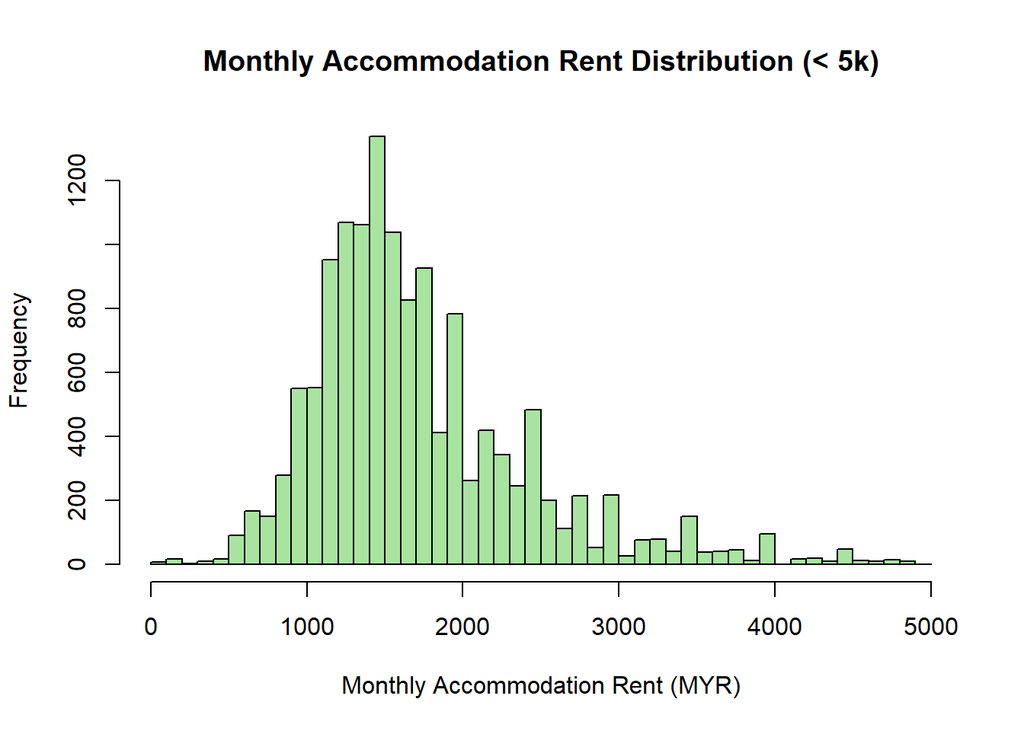

```r
hist_data_below <- hist_data[hist_data < 5000]

hist(
  hist_data_below, xlab = "Monthly Accommodation Rent (MYR)", main = "Monthly Accommodation Rent Distribution (< 5k)",
  col = "#A8E4A0", border = "black", breaks = 40
)
```

### Histogram of Property Size

This section shows a histogram of size. The diagram below will be only consist of the property size that is below than 3000 sq ft (<= 3000). Based on the summary results, the upper bound is about 1,100 (sq ft).

From the observation, most of the available property/accommodation will be falls into 700 to 1200 sq ft. Commonly, the size of the property will be around 750 sq ft to 1200 sq ft. In addition, most of the property size for rent is mostly available on 800 to 900 sq ft. This shows that in urban areas, more real estate developers focus more on urban development, since largest area means highest rent.

```r
hist_data_size <- (df_EDA$size)
summary(hist_data_size) #Show the summary
```

```
##     Min.  1st Qu.   Median     Mean  3rd Qu.     Max.
##        1      800      936     8235     1100 99999999
```

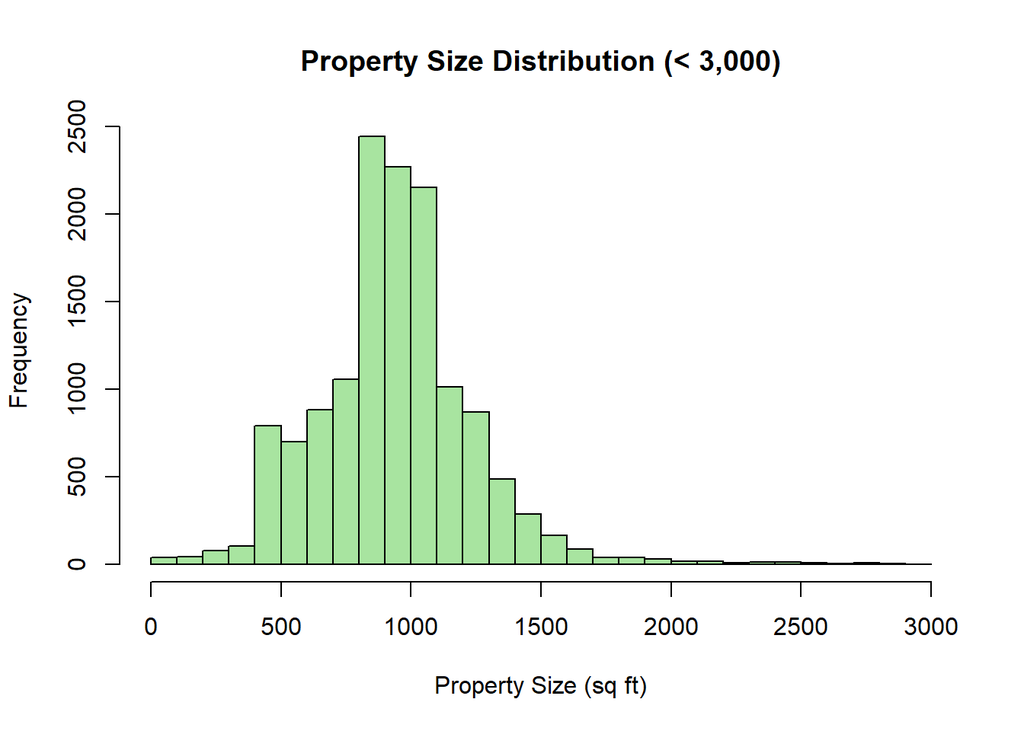

```r
hist_data_size_below <- hist_data_size[hist_data_size < 3000]

hist(
  hist_data_size_below, xlab = "Property Size (sq ft)", main = "Property Size Distribution (< 3,000)",
  col = "#A8E4A0", border = "black", breaks = 30
)
```

### Bar Chart of Property Attributes

1. parking: Present from 0 to 10, majority of the rent estate will be giving at least 1 car parking slot, but some provide 0 or 2 parking slot for tenant.
2. rooms: Illustrate that the accommodation/property are build as studio, single room, two room and mostly three room.
3. bathroom: Illustrate that for the majority of accommodation/property will having 2 bathroom. Since, majority of rooms is between 1 to 3, so that typically it will have 1 or 2 bathrooms.
4. completion_year: This show that massive of accommodation/property was starting arise after 2012. 2014 to 2022 is the peak period, indicating that due to the development of the city, the demand for accommodation is also rising.

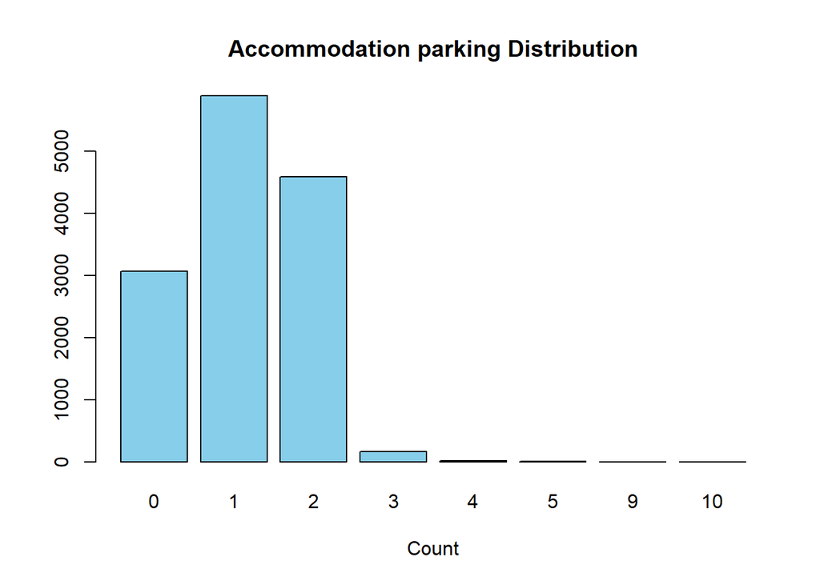

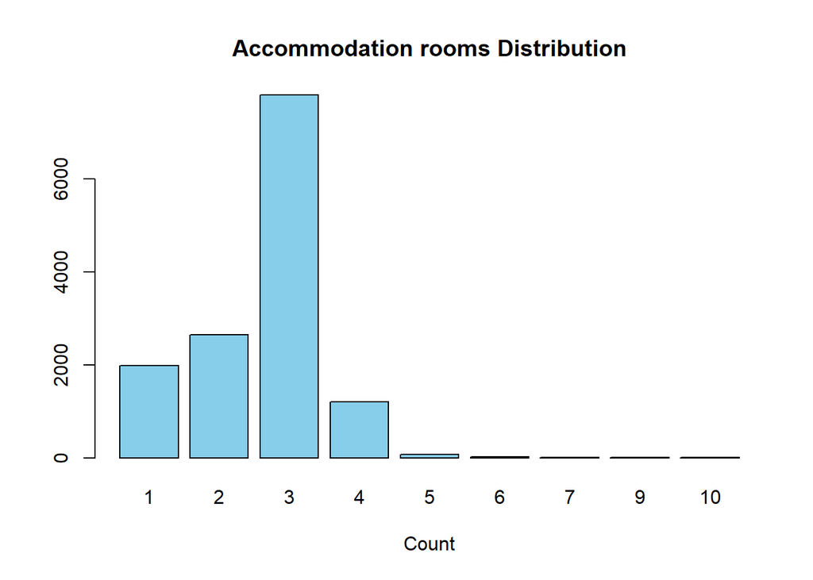

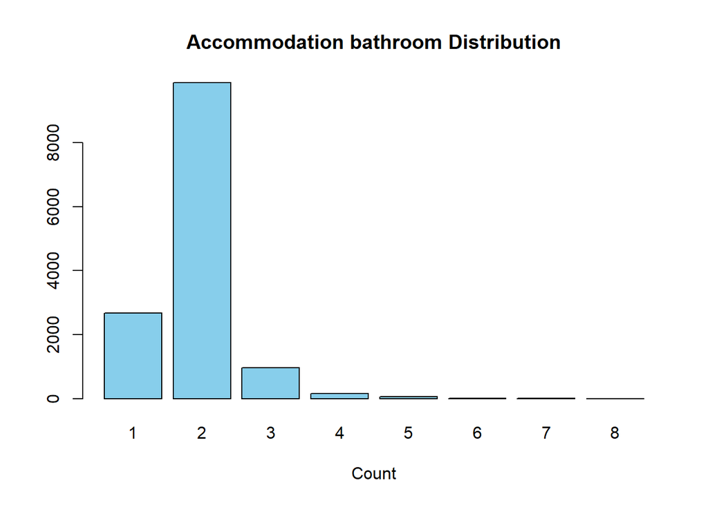

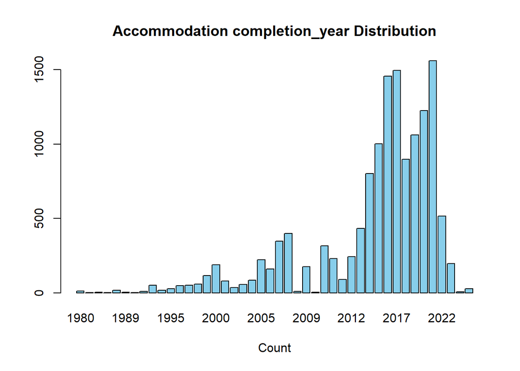

```r
plot_bar_chart_char <- function(bar_chart_columns) {

  for (col in bar_chart_columns) {
    counts_data <- df_EDA[[col]]

    unique(df_EDA$col)

    # Count occurrences
    category_counts <- table(counts_data)

    # Plot horizontal bar chart
    barplot(category_counts,
            col = "skyblue",
            main = paste("Accommodation" , col, "Distribution"),
            xlab = "Count")
  }
}

bar_chart_columns <- c("parking", "rooms", "bathroom", "completion_year")
plot_bar_chart_char(bar_chart_columns)
```

## Bivariate Analysis

### Pie Chart of Property Type

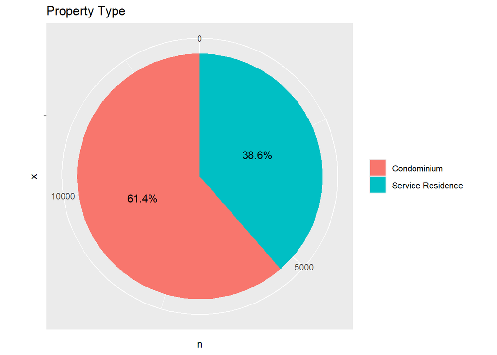

```r
property_data <- df_EDA %>% count(property_type)

ggplot(property_data, aes(x = "", y = n, fill = property_type)) +
  geom_bar(stat = "identity", width = 1) +
  coord_polar("y", start = 0) +
  geom_text(aes(label = paste0(round(n / sum(n) * 100, 1), "%")), position = position_stack(vjust = 0.5)) +
  labs(title = "Property Type") +
  theme(legend.title = element_blank())
```

### Pie Chart of Near Public Transport

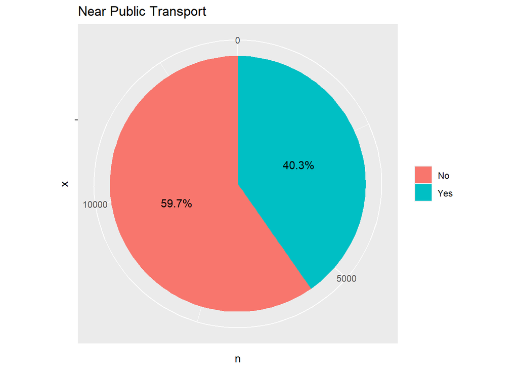

```r
near_public_transport_data <- df_EDA %>% count(near_public_transport)

near_public_transport_data$near_public_transport[near_public_transport_data$near_public_transport == 0] <- "No"
near_public_transport_data$near_public_transport[near_public_transport_data$near_public_transport == 1] <- "Yes"

ggplot(near_public_transport_data, aes(x = "", y = n, fill = near_public_transport)) +
  geom_bar(stat = "identity", width = 1) +
  coord_polar("y", start = 0) +
  geom_text(aes(label = paste0(round(n / sum(n) * 100, 1), "%")), position = position_stack(vjust = 0.5)) +
  labs(title = "Near Public Transport") +
  theme(legend.title = element_blank())
```

### Pie Chart of Furnished Type

This pie chart illustrate the distribution of the furnished type as “Fully Furnished”, “Not Furnished”, and “Partially Furnished”. From the observation, that most houses/properties provide tenants with fully furnished/partially furnished, with the results showing that 52.4% of accommodation/properties provide fully furnished, 38.2% of houses/properties provide partially furnished, and 9.4% of houses/properties do not provide any furniture.

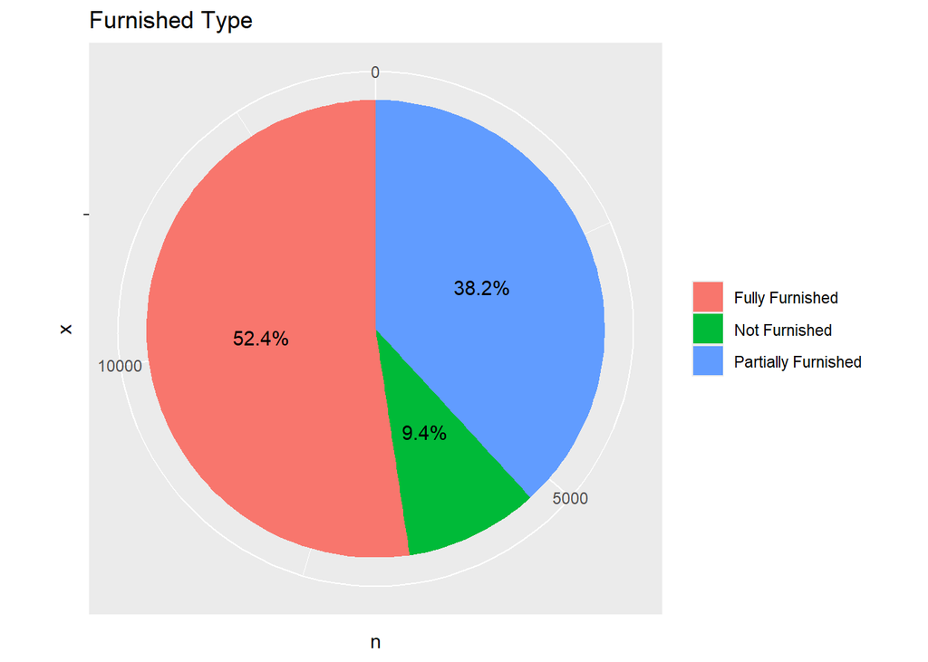

```r
furnished_data <- df_EDA %>% count(furnished)

ggplot(furnished_data, aes(x = "", y = n, fill = furnished)) +
  geom_bar(stat = "identity", width = 1) +
  coord_polar("y", start = 0) +
  geom_text(aes(label = paste0(round(n / sum(n) * 100, 1), "%")), position = position_stack(vjust = 0.5)) +
  labs(title = "Furnished Type") +
  theme(legend.title = element_blank())
```

## Multivariate Analysis

### BoxPlot - Two Relationship

In this section, the team will using boxplot to understand the relationship between monthly rent and property size. The boxplot is filtered based on the upper range to provide a clear visualization.

In the diagram show below, it clearly show a positive trend as the size increase the monthly rent also getting increase. This indicate the size of the accommodation/property will be related to the rent. In addition, there is outlines above and below of the box plot suggest that some properties may be high-end listings or quick-rent properties that are older and poorly maintained.

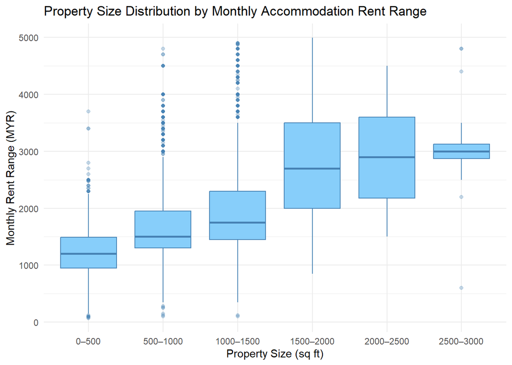

```r
#Define the bin size
breaks <- seq(0, 3000, by = 500)
rent_size_label <- paste(head(breaks, -1), tail(breaks, -1), sep = "–") #Set the rent_size range ([0],[1])

# Filter the size < 3000 and rent < 5000
boxplot_data_filter <- df_EDA %>%
  filter(size < 3000, monthly_rent < 5000) %>%
  mutate(property_size_bin = cut(size, breaks = breaks, labels = rent_size_label))

# Box plot: Size by Rent Range
ggplot(boxplot_data_filter, aes(x = property_size_bin, y = monthly_rent)) +
  geom_boxplot(fill = "#87CEFA", color = "#4682B4", outlier.alpha = 0.3) +
  labs(
    title = "Property Size Distribution by Monthly Accommodation Rent Range",
    x = "Property Size (sq ft)",
    y = "Monthly Rent Range (MYR)"
  ) +
  theme_minimal() +
  theme(axis.text.x = element_text(hjust = 0.5))
```

In this section, present the top 20 frequency locations that appear inside the dataset, which also reflect where the majority of the accommodation/properties are built and located. In addition, from the observation that areas like Mont Kiara or KLCC contain higher rent per month, and like Kajang, Cyberjaya, or Cheras which giving more affordable rent for lower budgets renters.

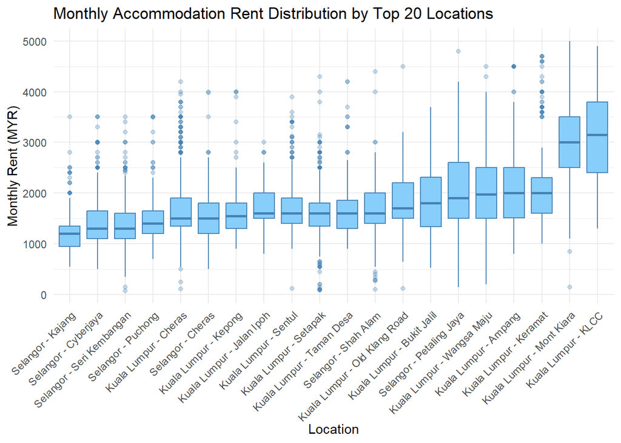

```r
# Filter the data
most_frequent_locations <- df_EDA %>%
  count(location, sort = TRUE) #Find the most frequency location

#Filter top 20 location and < 5000 money rent
boxplot_data_filter <- df_EDA %>%
  filter(monthly_rent < 5000, location %in% most_frequent_locations$location[0:20])

ggplot(boxplot_data_filter, aes(x = reorder(location, monthly_rent, median), y = monthly_rent)) +
  geom_boxplot(fill = "#87CEFA", color = "#4682B4", outlier.alpha = 0.3) +
  labs(
    title = "Monthly Accommodation Rent Distribution by Top 20 Locations",
    x = "Location",
    y = "Monthly Rent (MYR)"
  ) +
  theme_minimal() +
  theme(axis.text.x = element_text(angle = 45, hjust = 1))
```

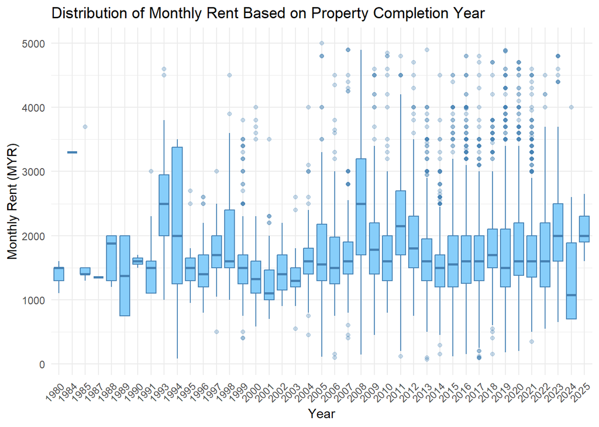

```r
#Arrange completion year and < 5000 money rent
boxplot_data_filter <- df_EDA %>%
  mutate(completion_year = as.integer(completion_year)) %>%
  filter(monthly_rent < 5000) %>%
  arrange(completion_year)

#Using factor() arrange into categories type (Grouping)
boxplot_data_filter$completion_year <- factor(
  boxplot_data_filter$completion_year
)

ggplot(boxplot_data_filter, aes(x = completion_year, y = monthly_rent)) +
  geom_boxplot(fill = "#87CEFA", color = "#4682B4", outlier.alpha = 0.3) +
  labs(
    title = "Distribution of Monthly Rent Based on Property Completion Year",
    x = "Year",
    y = "Monthly Rent (MYR)"
  ) +
  theme_minimal() +
  theme(axis.text.x = element_text(angle = 45, hjust = 1))
```

In this boxplot illustrate that the monlthy rents will follow the furnished to increase, it indicate that an accommodation/property with fully furnished will have the average that is above RM1,500 and for partially furnished will be around RM1,300 and above, then for not furnished the overall average will be the lowest as around RM1,000 and above. However, this also shows that for landlords, fully furnished tenants are more willing to rent out their properties because it also provides more convenience for students and workers tenants, and tenants do not need to make further purchases.

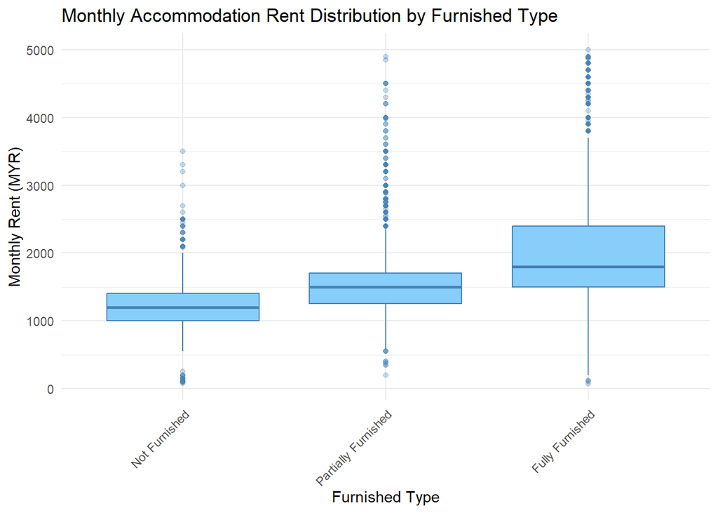

```r
#Filter < 5000 money rent
boxplot_data_filter <- df_EDA %>%
  filter(monthly_rent < 5000)

ggplot(boxplot_data_filter, aes(x = reorder(furnished, monthly_rent, median), y = monthly_rent)) +
  geom_boxplot(fill = "#87CEFA", color = "#4682B4", outlier.alpha = 0.3) +
  labs(
    title = "Monthly Accommodation Rent Distribution by Furnished Type",
    x = "Furnished Type",
    y = "Monthly Rent (MYR)"
  ) +
  theme_minimal() +
  theme(axis.text.x = element_text(angle = 45, hjust = 1))
```

## Correlation Matrix

This section showcase a correlation matrix between each feature.

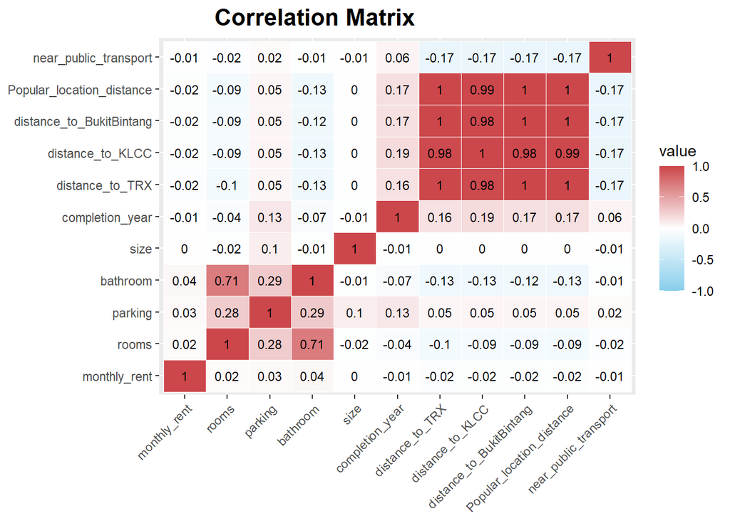

```r
heatmap_data <- df_EDA %>%
  select(where(is.numeric)) #Select only numeric data (remove such as prop_name, e.g.)

heatmap_data <- heatmap_data %>% select(-ads_id)  #Remove ads_id

corr_data <- cor(heatmap_data, use = "complete.obs") #Transfer into numeric (-1 , 1)
melted_corr <- melt(corr_data) #into a format for ggplot
heap_map_color <- colorRampPalette(c("skyblue", "white", "#cc474b"))(200)

# Plot
ggplot(melted_corr, aes(x = Var1, y = Var2, fill = value)) +
  geom_tile(color = "white") +
  geom_text(aes(label = round(value,2)), size = 3) +
  scale_fill_gradientn(colors = heap_map_color, limits = c(-1, 1)) +
  labs(title = "Correlation Matrix", x = NULL, y = NULL) + #Add NULL else will have Var2 and Var1
  theme(
    axis.text.x = element_text(angle = 45, hjust = 1),
    plot.title = element_text(hjust = 0.2, size = 16, face = "bold")
  )
```

# Feature Engineering

```r
df_feature = data.frame(df_EDA) #Make a copy for Data Modelling
head(df_feature)
```

```
##     ads_id       prop_name monthly_rent                   location
## 1 16525511 Villa Wangsamas         2000 Kuala Lumpur - Wangsa Maju
## 2 16572317 Villa Wangsamas         1700 Kuala Lumpur - Wangsa Maju
## 3 16717632 Villa Wangsamas         2000 Kuala Lumpur - Wangsa Maju
## 4 16801236 Villa Wangsamas         2000 Kuala Lumpur - Wangsa Maju
## 5 17122588 Villa Wangsamas         2000 Kuala Lumpur - Wangsa Maju
## 6 17465265 Villa Wangsamas         2000 Kuala Lumpur - Wangsa Maju
##   property_type rooms parking bathroom size           furnished
## 1   Condominium     3       0        3 1267     Fully Furnished
## 2   Condominium     3       0        3 1267 Partially Furnished
## 3   Condominium     3       1        3 1267     Fully Furnished
## 4   Condominium     3       0        3 1267     Fully Furnished
## 5   Condominium     3       0        3 1267     Fully Furnished
## 6   Condominium     3       0        3 1267     Fully Furnished
##                                                                                                                             facilities
```

[output cut: 34 more lines]

In this section, the team will filter outliers from the dataset. Based on the early indications from the histogram and boxplot, most monthly rents are below $5,000, housing size is below $3,000, and the room, package, and bathroom sizes are below 6, 4, and 4, respectively. Therefore, the team will filter the data to try to keep a large sample size within the dataset.

```r
df_feature <- df_feature %>% filter(monthly_rent > 400 & monthly_rent < 5000)
df_feature <- df_feature %>% filter(size > 100 & size < 3000)
df_feature <- df_feature %>% filter(rooms > 0 & rooms < 6)
df_feature <- df_feature %>% filter(parking > 0 & parking < 4)
df_feature <- df_feature %>% filter(bathroom > 0 & bathroom < 4)

head(df_feature)
```

```
##     ads_id       prop_name monthly_rent                      location
## 1 16717632 Villa Wangsamas         2000    Kuala Lumpur - Wangsa Maju
## 2 18186927 Villa Wangsamas         2000    Kuala Lumpur - Wangsa Maju
## 3 18677373 Villa Wangsamas         2000    Kuala Lumpur - Wangsa Maju
## 4 42927744  Majestic Maxim          900         Kuala Lumpur - Cheras
## 5 44085509                         1400 Kuala Lumpur - Old Klang Road
## 6 45057687                         1200          Selangor - Shah Alam
##       property_type rooms parking bathroom size           furnished
## 1       Condominium     3       1        3 1267     Fully Furnished
## 2       Condominium     3       1        3 1267     Fully Furnished
## 3       Condominium     3       1        3 1267     Fully Furnished
## 4 Service Residence     3       1        2  780       Not Furnished
## 5 Service Residence     1       1        2  775     Fully Furnished
## 6       Condominium     2       1        2  759 Partially Furnished
##                                                                                                                             facilities
```

[output cut: 34 more lines]

In this section, the team will perform coverting process on the dataset to prepare it for data modelling. Firstly, the team will recode the furnished column transforming the string value into numeric values “Fully Furnished” is assigned 1, “Partially Furnished” is 2, and “Not Furnished” is 3. Similar r ecode for the property type “Condominium” becomes 1 and “Service Residence” becomes 0.

Next, the team will create a new column for calculate the year built from the current year, and forming “property_age” column. Then will combines the facilities and additional facilities columns into a single column, after that removing corruption data such as containing numebric, only keep as valid character of form. In addition, calculate the number of facilities and stored inside a new column “number_facilities”.

```r
# Make a copy (assuming df_feature exists)
df_feature_prepare = data.frame(df_feature)

# ---------------------------------------------------------------------------------
# Recode 'furnished' column
df_feature_prepare$furnished <- df_feature_prepare$furnished %>%
  recode(
    "Fully Furnished" = 1,
    "Partially Furnished" = 2,
    "Not Furnished" = 3
  ) %>%
  as.numeric()


# ---------------------------------------------------------------------------------
# Recode 'property_type'
df_feature_prepare$property_type <- df_feature_prepare$property_type %>%
  recode(
    "Condominium" = 1,
    "Service Residence" = 0
  ) %>%
  as.numeric()

# ---------------------------------------------------------------------------------
# Transform the 'completion_year' column to age of the property
current_year <- 2025
df_feature_prepare$property_age <- current_year - df_feature_prepare$completion_year

# ---------------------------------------------------------------------------------
# Combine both 'facilities' and 'additional facilities' columns

# Ensure both columns are character type before pasting to avoid issues with factors
df_feature_prepare$facilities <- as.character(df_feature_prepare$facilities)
df_feature_prepare$additional_facilities <- as.character(df_feature_prepare$additional_facilities)

# Column combining
df_combined_facilities <- df_feature_prepare %>%
  mutate(facilities_combined = paste(facilities, additional_facilities, sep = ", "))
# ---------------------------------------------------------------------------------

# Remove unwanted characters such as 10, 11, 6 in 'facilities' column
df_combined_facilities$facilities_combined <- gsub("[^a-zA-Z, ]", "", df_combined_facilities$facilities_combined)

# Count the number of facilities from 'facilities_combined'
df_facilities <- df_combined_facilities %>%
  mutate(number_facilities = sapply(strsplit(facilities_combined, ", "), length))

# ---------------------------------------------------------------------------------
#Data Attribute selection
keep_columns <- c("rooms", "parking", "bathroom", "near_public_transport",
                  "monthly_rent", "size", "Popular_location_distance",
                  "property_type", "furnished", "property_age", "number_facilities"
                  , "location")

# Filter the wanted columns for data modelling
df_final_prepared <- df_facilities %>% select(any_of(keep_columns))

df_final_prepared$location <- factor(df_final_prepared$location)

head(df_final_prepared)
```

```
##   rooms parking bathroom near_public_transport monthly_rent size
## 1     3       1        3                     1         2000 1267
## 2     3       1        3                     1         2000 1267
## 3     3       1        3                     1         2000 1267
## 4     3       1        2                     1          900  780
## 5     1       1        2                     0         1400  775
## 6     2       1        2                     0         1200  759
##   Popular_location_distance property_type furnished property_age
## 1                  10.80067             1         1           15
## 2                  10.80067             1         1           15
## 3                  10.80067             1         1           15
## 4                  10.23533             0         3            4
## 5                   9.03800             0         1            9
## 6                  27.16700             1         2           10
##   number_facilities                      location
## 1                16    Kuala Lumpur - Wangsa Maju
## 2                16    Kuala Lumpur - Wangsa Maju
## 3                16    Kuala Lumpur - Wangsa Maju
## 4                12         Kuala Lumpur - Cheras
## 5                 7 Kuala Lumpur - Old Klang Road
## 6                13          Selangor - Shah Alam
```

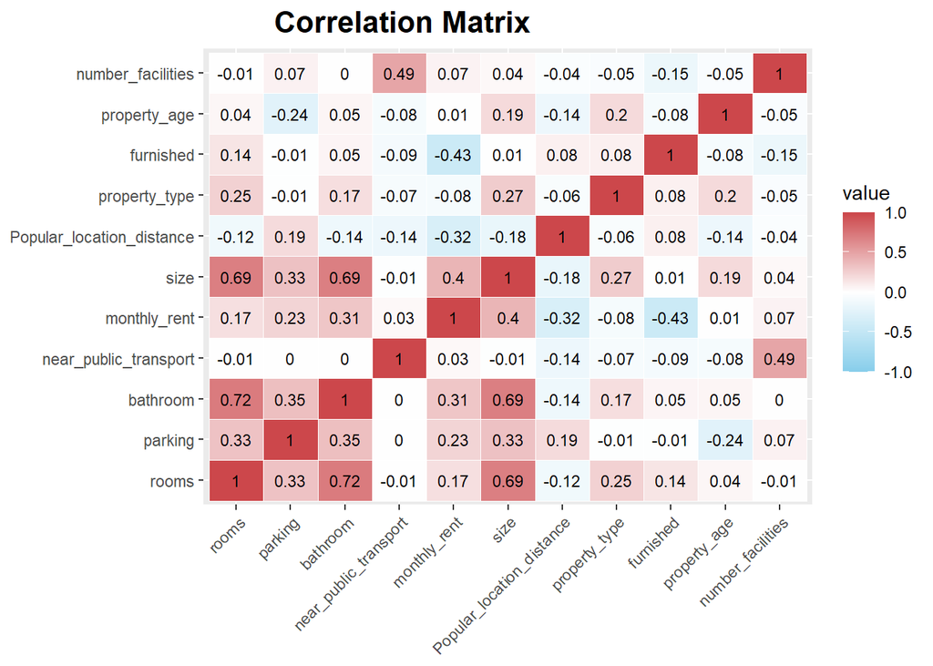

```r
heatmap_data <- df_final_prepared %>%
  select(where(is.numeric)) #Select only numeric data (remove such as prop_name, e.g.)

corr_data <- cor(heatmap_data, use = "complete.obs") #Transfer into numeric (-1 , 1)
melted_corr <- melt(corr_data) #into a format for ggplot
heap_map_color <- colorRampPalette(c("skyblue", "white", "#cc474b"))(200)

# Plot
ggplot(melted_corr, aes(x = Var1, y = Var2, fill = value)) +
  geom_tile(color = "white") +
  geom_text(aes(label = round(value,2)), size = 3) +
  scale_fill_gradientn(colors = heap_map_color, limits = c(-1, 1)) +
  labs(title = "Correlation Matrix", x = NULL, y = NULL) + #Add NULL else will have Var2 and Var1
  theme(
    axis.text.x = element_text(angle = 45, hjust = 1),
    plot.title = element_text(hjust = 0.2, size = 16, face = "bold")
  )
```